# IDS576A1Q5

Problem 5: MNIST Hand-written Digit Recognition

(a) Code a function that displays at least one image per each digit.

```python
import pandas as pd
import matplotlib.pyplot as plt
import numpy as np
traindata = pd.read_csv("train.csv")
```

```python
data = pd.DataFrame(data=traindata)
```

```python
target = data.loc[:,'label']
```

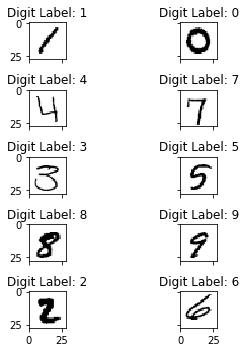

```python
images_to_plot = 10
indices = target.drop_duplicates()

sample_images = data.drop_duplicates('label').drop("label", axis=1)
sample_labels = target.drop_duplicates()

plt.clf()
plt.style.use('seaborn-muted')

fig, axes = plt.subplots(5,2,
                         figsize=(5,5),
                         sharex=True, sharey=True)

for i in range(images_to_plot):

    # axes (subplot) objects are stored in 2d array, accessed with axes[row,col]
    subplot_row = i//2
    subplot_col = i%2
    ax = axes[subplot_row, subplot_col]

    # plot image on subplot
    plottable_image = np.reshape(sample_images.iloc[i,:].values, (28,28))
    ax.imshow(plottable_image, cmap='gray_r')

    ax.set_title('Digit Label: {}'.format(sample_labels.iloc[i]))
    ax.set_xbound([0,28])

plt.tight_layout()
plt.show()
```

(b) Measure the distribution over the labels in the training data.

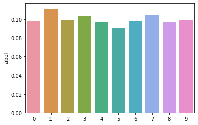

```python
distribution = target.value_counts(normalize=True)
import seaborn
seaborn.barplot(x=distribution.index, y=distribution)
```

We observe that the distribution of digits in the training data is almost uniform so it is fit for modelling. Digit 1 has slightly more rows in the data compared to digit 5.

(c) Implement a multiclass classification via logistic regression and try to vary the parameters so that you can achieve the best performance on our Kaggle dataset.

```python
# Standarize the data
from sklearn.preprocessing import StandardScaler

Y_train = data["label"]
X_train = data.drop("label", axis=1)

scaler = StandardScaler()
X_train = scaler.fit_transform(X_train)

X_train
```

```
array([[0., 0., 0., ..., 0., 0., 0.],
       [0., 0., 0., ..., 0., 0., 0.],
       [0., 0., 0., ..., 0., 0., 0.],
       ...,
       [0., 0., 0., ..., 0., 0., 0.],
       [0., 0., 0., ..., 0., 0., 0.],
       [0., 0., 0., ..., 0., 0., 0.]])
```

```python
random_seed = 3
from sklearn.linear_model import LogisticRegression
from sklearn.model_selection import train_test_split

train_img, test_img, train_lbl, test_lbl = train_test_split(
    X_train, Y_train, test_size=1/7.0, random_state=122)

train_samples = train_img.shape[0]

model_1 = LogisticRegression(
    C=50. / train_samples, penalty='l1', solver='saga', tol=0.1, class_weight='balanced',multi_class='auto')

model_2 = LogisticRegression(
    C=50. / train_samples, penalty='l2', solver='saga', tol=0.1, class_weight='balanced',multi_class='auto')


model_1.fit(train_img, train_lbl)
model_2.fit(train_img, train_lbl)
```

```
LogisticRegression(C=0.001388888888888889, class_weight='balanced', dual=False,
                   fit_intercept=True, intercept_scaling=1, l1_ratio=None,
                   max_iter=100, multi_class='auto', n_jobs=None, penalty='l2',
                   random_state=None, solver='saga', tol=0.1, verbose=0,
                   warm_start=False)
```

```python
sparsity = np.mean(model_1.coef_ == 0) * 100
score = model_1.score(test_img, test_lbl)
```

```python
sparsity = np.mean(model_2.coef_ == 0) * 100
score = model_2.score(test_img, test_lbl)
```

```python
print(sparsity)
print(score)

model_1.coef_.shape
```

```
9.693877551020408
0.8866666666666667
```

```
(10, 784)
```

```python
print(sparsity)
print(score)

model_2.coef_.shape
```

```
9.693877551020408
0.8866666666666667
```

```
(10, 784)
```

```python
from sklearn import metrics

y_pred = model_1.predict(test_img)
count_misclassified = (test_lbl != y_pred).sum()

print('Misclassified samples: {}'.format(count_misclassified))
accuracy = metrics.accuracy_score(test_lbl, y_pred)
print('Accuracy: {:.2f}'.format(accuracy))
```

```
Misclassified samples: 954
Accuracy: 0.84
```

```python
from sklearn import metrics

y_pred = model_2.predict(test_img)
count_misclassified = (test_lbl != y_pred).sum()

print('Misclassified samples: {}'.format(count_misclassified))
accuracy = metrics.accuracy_score(test_lbl, y_pred)
print('Accuracy: {:.2f}'.format(accuracy))
```

```
Misclassified samples: 680
Accuracy: 0.89
```

Logistic Regression with L2 penalty (Ridge) gives a better model with accuracy of 89%.

(d) Implement a neural-net classifier with varying the number of hidden layers and neurons there.

```python
import numpy as np
import pandas as pd
import matplotlib.pyplot as plt

# train test split from sklearn
from sklearn.model_selection import train_test_split

# Import Torch
import torch
import torch.nn as nn
from torchvision import transforms, models

from torch.autograd import Variable
from torch import nn, optim
import torch.nn.functional as F


test = pd.read_csv("test.csv")
train = pd.read_csv("train.csv")
sample_sub = pd.read_csv("sample_submission.csv")
```

```python
# Seperate the features and labels and normalize them on scale of 0-1
targets_np = train.label.values
features_np = train.loc[:, train.columns != 'label'].values/255

# Split into training and test set
features_train, features_test, target_train, target_test = train_test_split(features_np, targets_np, test_size=0.2, random_state=42)
```

```python
# create feature and targets tensor for train set
featuresTrain = torch.from_numpy(features_train)
targetsTrain = torch.from_numpy(target_train).type(torch.LongTensor)

# create feature and targets tensor for test set.
featuresTest = torch.from_numpy(features_test)
targetsTest = torch.from_numpy(target_test).type(torch.LongTensor)
```

```python
# Set batch size
batch_size = 256

# Pytorch train and test sets
train = torch.utils.data.TensorDataset(featuresTrain,targetsTrain)
test = torch.utils.data.TensorDataset(featuresTest,targetsTest)

# data loader
train_loader = torch.utils.data.DataLoader(train, batch_size = batch_size, shuffle = True)
test_loader = torch.utils.data.DataLoader(test, batch_size = batch_size, shuffle = True)
```

```python
#Train-Test data distribution
print(featuresTrain.shape)
print(featuresTest.shape)
```

```
torch.Size([33600, 784])
torch.Size([8400, 784])
```

```python
class Classifier1(nn.Module):
    def __init__(self):
        super().__init__()
        # 5 Hidden Layer Network
        self.fc1 = nn.Linear(28*28, 512)
        self.fc2 = nn.Linear(512, 256)
        self.fc3 = nn.Linear(256, 128)
        self.fc4 = nn.Linear(128, 64)
        self.fc5 = nn.Linear(64, 10)

        # Dropout module with 0.2 probbability
        self.dropout = nn.Dropout(p=0.2)
        # Add softmax on output layer
        self.log_softmax = F.log_softmax

    def forward(self, x):
        x = self.dropout(F.relu(self.fc1(x)))
        x = self.dropout(F.relu(self.fc2(x)))
        x = self.dropout(F.relu(self.fc3(x)))
        x = self.dropout(F.relu(self.fc4(x)))

        x = self.log_softmax(self.fc5(x), dim=1)

        return x
```

```python
class Classifier2(nn.Module):
    def __init__(self):
        super().__init__()
        # 5 Hidden Layer Network
        self.fc1 = nn.Linear(28*28, 512)
        self.fc2 = nn.Linear(512, 256)
        self.fc3 = nn.Linear(256, 64)
        self.fc4 = nn.Linear(64, 10)

        # Dropout module with 0.2 probbability
        self.dropout = nn.Dropout(p=0.2)
        # Add softmax on output layer
        self.log_softmax = F.log_softmax

    def forward(self, x):
        x = self.dropout(F.relu(self.fc1(x)))
        x = self.dropout(F.relu(self.fc2(x)))
        x = self.dropout(F.relu(self.fc3(x)))

        x = self.log_softmax(self.fc4(x), dim=1)

        return x
```

```python
class Classifier3(nn.Module):
    def __init__(self):
        super().__init__()
        # 5 Hidden Layer Network
        self.fc1 = nn.Linear(28*28, 512)
        self.fc2 = nn.Linear(512, 64)
        self.fc3 = nn.Linear(64, 10)

        # Dropout module with 0.2 probbability
        self.dropout = nn.Dropout(p=0.2)
        # Add softmax on output layer
        self.log_softmax = F.log_softmax

    def forward(self, x):
        x = self.dropout(F.relu(self.fc1(x)))
        x = self.dropout(F.relu(self.fc2(x)))

        x = self.log_softmax(self.fc3(x), dim=1)

        return x
```

```python
# Instantiate model 1
model1 = Classifier1()
# Define our loss function
criterion = nn.NLLLoss()
# Define the optimier
optimizer = optim.Adam(model1.parameters(), lr=0.0015)

epochs = 25
steps = 0
print_every = 50
train_losses, test_losses = [], []

for e in range(epochs):
    running_loss = 0
    for images, labels in train_loader:
        steps += 1
        # Prevent accumulation of gradients
        optimizer.zero_grad()
        # Make predictions
        log_ps = model1(images.float())
        loss = criterion(log_ps, labels)
        #backprop
        loss.backward()
        optimizer.step()

        running_loss += loss.item()
        if steps % print_every == 0:
            test_loss = 0
            accuracy = 0

            # Turn off gradients for validation
            with torch.no_grad():
                model1.eval()
                for images, labels in test_loader:
                    log_ps = model1(images.float())
                    test_loss += criterion(log_ps, labels)

                    ps = torch.exp(log_ps)
                    # Get our top predictions
                    top_p, top_class = ps.topk(1, dim=1)
                    equals = top_class == labels.view(*top_class.shape)
                    accuracy += torch.mean(equals.type(torch.FloatTensor))

            model1.train()

            train_losses.append(running_loss/len(train_loader))
            test_losses.append(test_loss/len(test_loader))

            print("Epoch: {}/{}.. ".format(e+1, epochs),
                  "Training Loss: {:.3f}.. ".format(train_losses[-1]),
                  "Test Loss: {:.3f}.. ".format(test_losses[-1]),
                  "Test Accuracy: {:.3f}".format(accuracy/len(test_loader)))
```

```
Epoch: 1/25..  Training Loss: 0.452..  Test Loss: 0.479..  Test Accuracy: 0.860
Epoch: 1/25..  Training Loss: 0.617..  Test Loss: 0.293..  Test Accuracy: 0.913
Epoch: 2/25..  Training Loss: 0.037..  Test Loss: 0.206..  Test Accuracy: 0.936
Epoch: 2/25..  Training Loss: 0.122..  Test Loss: 0.170..  Test Accuracy: 0.948
Epoch: 2/25..  Training Loss: 0.193..  Test Loss: 0.147..  Test Accuracy: 0.956
Epoch: 3/25..  Training Loss: 0.043..  Test Loss: 0.135..  Test Accuracy: 0.959
Epoch: 3/25..  Training Loss: 0.098..  Test Loss: 0.140..  Test Accuracy: 0.957
Epoch: 4/25..  Training Loss: 0.004..  Test Loss: 0.143..  Test Accuracy: 0.956
Epoch: 4/25..  Training Loss: 0.043..  Test Loss: 0.119..  Test Accuracy: 0.966
Epoch: 4/25..  Training Loss: 0.087..  Test Loss: 0.104..  Test Accuracy: 0.970
Epoch: 5/25..  Training Loss: 0.017..  Test Loss: 0.110..  Test Accuracy: 0.968
Epoch: 5/25..  Training Loss: 0.055..  Test Loss: 0.091..  Test Accuracy: 0.973
Epoch: 5/25..  Training Loss: 0.090..  Test Loss: 0.102..  Test Accuracy: 0.970
Epoch: 6/25..  Training Loss: 0.022..  Test Loss: 0.104..  Test Accuracy: 0.970
Epoch: 6/25..  Training Loss: 0.050..  Test Loss: 0.104..  Test Accuracy: 0.970
Epoch: 7/25..  Training Loss: 0.004..  Test Loss: 0.113..  Test Accuracy: 0.967
Epoch: 7/25..  Training Loss: 0.030..  Test Loss: 0.096..  Test Accuracy: 0.972
Epoch: 7/25..  Training Loss: 0.057..  Test Loss: 0.093..  Test Accuracy: 0.973
Epoch: 8/25..  Training Loss: 0.013..  Test Loss: 0.096..  Test Accuracy: 0.974
Epoch: 8/25..  Training Loss: 0.035..  Test Loss: 0.095..  Test Accuracy: 0.973
Epoch: 8/25..  Training Loss: 0.057..  Test Loss: 0.092..  Test Accuracy: 0.975
Epoch: 9/25..  Training Loss: 0.015..  Test Loss: 0.089..  Test Accuracy: 0.975
Epoch: 9/25..  Training Loss: 0.034..  Test Loss: 0.094..  Test Accuracy: 0.975
Epoch: 10/25..  Training Loss: 0.004..  Test Loss: 0.101..  Test Accuracy: 0.975
Epoch: 10/25..  Training Loss: 0.021..  Test Loss: 0.100..  Test Accuracy: 0.975
Epoch: 10/25..  Training Loss: 0.038..  Test Loss: 0.107..  Test Accuracy: 0.974
Epoch: 11/25..  Training Loss: 0.010..  Test Loss: 0.105..  Test Accuracy: 0.973
Epoch: 11/25..  Training Loss: 0.025..  Test Loss: 0.100..  Test Accuracy: 0.975
Epoch: 11/25..  Training Loss: 0.043..  Test Loss: 0.097..  Test Accuracy: 0.976
Epoch: 12/25..  Training Loss: 0.012..  Test Loss: 0.092..  Test Accuracy: 0.977
Epoch: 12/25..  Training Loss: 0.026..  Test Loss: 0.101..  Test Accuracy: 0.976
Epoch: 13/25..  Training Loss: 0.004..  Test Loss: 0.104..  Test Accuracy: 0.977
Epoch: 13/25..  Training Loss: 0.018..  Test Loss: 0.100..  Test Accuracy: 0.977
Epoch: 13/25..  Training Loss: 0.032..  Test Loss: 0.097..  Test Accuracy: 0.974
Epoch: 14/25..  Training Loss: 0.010..  Test Loss: 0.105..  Test Accuracy: 0.975
Epoch: 14/25..  Training Loss: 0.024..  Test Loss: 0.100..  Test Accuracy: 0.976
Epoch: 15/25..  Training Loss: 0.000..  Test Loss: 0.090..  Test Accuracy: 0.979
Epoch: 15/25..  Training Loss: 0.009..  Test Loss: 0.111..  Test Accuracy: 0.975
Epoch: 15/25..  Training Loss: 0.019..  Test Loss: 0.091..  Test Accuracy: 0.978
Epoch: 16/25..  Training Loss: 0.004..  Test Loss: 0.105..  Test Accuracy: 0.976
```

[output cut: 11 more lines]

```
Epoch: 20/25..  Training Loss: 0.015..  Test Loss: 0.145..  Test Accuracy: 0.972
Epoch: 21/25..  Training Loss: 0.002..  Test Loss: 0.102..  Test Accuracy: 0.977
Epoch: 21/25..  Training Loss: 0.009..  Test Loss: 0.100..  Test Accuracy: 0.978
Epoch: 21/25..  Training Loss: 0.016..  Test Loss: 0.108..  Test Accuracy: 0.978
Epoch: 22/25..  Training Loss: 0.003..  Test Loss: 0.101..  Test Accuracy: 0.978
Epoch: 22/25..  Training Loss: 0.011..  Test Loss: 0.111..  Test Accuracy: 0.977
Epoch: 22/25..  Training Loss: 0.019..  Test Loss: 0.108..  Test Accuracy: 0.978
Epoch: 23/25..  Training Loss: 0.006..  Test Loss: 0.112..  Test Accuracy: 0.978
Epoch: 23/25..  Training Loss: 0.015..  Test Loss: 0.110..  Test Accuracy: 0.979
Epoch: 24/25..  Training Loss: 0.001..  Test Loss: 0.098..  Test Accuracy: 0.978
Epoch: 24/25..  Training Loss: 0.007..  Test Loss: 0.104..  Test Accuracy: 0.979
Epoch: 24/25..  Training Loss: 0.012..  Test Loss: 0.110..  Test Accuracy: 0.979
Epoch: 25/25..  Training Loss: 0.006..  Test Loss: 0.112..  Test Accuracy: 0.978
Epoch: 25/25..  Training Loss: 0.013..  Test Loss: 0.104..  Test Accuracy: 0.980
Epoch: 25/25..  Training Loss: 0.022..  Test Loss: 0.109..  Test Accuracy: 0.978
```

```python
# Instantiate model 2
model = Classifier2()
# Define our loss function
criterion = nn.NLLLoss()
# Define the optimier
optimizer = optim.Adam(model.parameters(), lr=0.0015)

epochs = 25
steps = 0
print_every = 50
train_losses, test_losses = [], []

for e in range(epochs):
    running_loss = 0
    for images, labels in train_loader:
        steps += 1
        # Prevent accumulation of gradients
        optimizer.zero_grad()
        # Make predictions
        log_ps = model(images.float())
        loss = criterion(log_ps, labels)
        #backprop
        loss.backward()
        optimizer.step()

        running_loss += loss.item()
        if steps % print_every == 0:
            test_loss = 0
            accuracy = 0

            # Turn off gradients for validation
            with torch.no_grad():
                model.eval()
                for images, labels in test_loader:
                    log_ps = model(images.float())
                    test_loss += criterion(log_ps, labels)

                    ps = torch.exp(log_ps)
                    # Get our top predictions
                    top_p, top_class = ps.topk(1, dim=1)
                    equals = top_class == labels.view(*top_class.shape)
                    accuracy += torch.mean(equals.type(torch.FloatTensor))

            model.train()

            train_losses.append(running_loss/len(train_loader))
            test_losses.append(test_loss/len(test_loader))

            print("Epoch: {}/{}.. ".format(e+1, epochs),
                  "Training Loss: {:.3f}.. ".format(train_losses[-1]),
                  "Test Loss: {:.3f}.. ".format(test_losses[-1]),
                  "Test Accuracy: {:.3f}".format(accuracy/len(test_loader)))
```

```
Epoch: 1/25..  Training Loss: 0.380..  Test Loss: 0.370..  Test Accuracy: 0.888
Epoch: 1/25..  Training Loss: 0.514..  Test Loss: 0.266..  Test Accuracy: 0.919
Epoch: 2/25..  Training Loss: 0.029..  Test Loss: 0.219..  Test Accuracy: 0.931
Epoch: 2/25..  Training Loss: 0.109..  Test Loss: 0.177..  Test Accuracy: 0.945
Epoch: 2/25..  Training Loss: 0.179..  Test Loss: 0.144..  Test Accuracy: 0.955
Epoch: 3/25..  Training Loss: 0.040..  Test Loss: 0.128..  Test Accuracy: 0.963
Epoch: 3/25..  Training Loss: 0.092..  Test Loss: 0.131..  Test Accuracy: 0.958
Epoch: 4/25..  Training Loss: 0.003..  Test Loss: 0.134..  Test Accuracy: 0.960
Epoch: 4/25..  Training Loss: 0.043..  Test Loss: 0.109..  Test Accuracy: 0.966
Epoch: 4/25..  Training Loss: 0.083..  Test Loss: 0.110..  Test Accuracy: 0.964
Epoch: 5/25..  Training Loss: 0.015..  Test Loss: 0.104..  Test Accuracy: 0.970
Epoch: 5/25..  Training Loss: 0.047..  Test Loss: 0.098..  Test Accuracy: 0.970
Epoch: 5/25..  Training Loss: 0.078..  Test Loss: 0.098..  Test Accuracy: 0.970
Epoch: 6/25..  Training Loss: 0.019..  Test Loss: 0.089..  Test Accuracy: 0.973
Epoch: 6/25..  Training Loss: 0.049..  Test Loss: 0.096..  Test Accuracy: 0.971
Epoch: 7/25..  Training Loss: 0.003..  Test Loss: 0.097..  Test Accuracy: 0.972
Epoch: 7/25..  Training Loss: 0.026..  Test Loss: 0.103..  Test Accuracy: 0.971
Epoch: 7/25..  Training Loss: 0.047..  Test Loss: 0.094..  Test Accuracy: 0.972
Epoch: 8/25..  Training Loss: 0.011..  Test Loss: 0.094..  Test Accuracy: 0.973
Epoch: 8/25..  Training Loss: 0.029..  Test Loss: 0.099..  Test Accuracy: 0.973
Epoch: 8/25..  Training Loss: 0.050..  Test Loss: 0.086..  Test Accuracy: 0.975
Epoch: 9/25..  Training Loss: 0.014..  Test Loss: 0.094..  Test Accuracy: 0.972
Epoch: 9/25..  Training Loss: 0.030..  Test Loss: 0.093..  Test Accuracy: 0.975
Epoch: 10/25..  Training Loss: 0.004..  Test Loss: 0.098..  Test Accuracy: 0.974
Epoch: 10/25..  Training Loss: 0.017..  Test Loss: 0.096..  Test Accuracy: 0.974
Epoch: 10/25..  Training Loss: 0.034..  Test Loss: 0.092..  Test Accuracy: 0.974
Epoch: 11/25..  Training Loss: 0.007..  Test Loss: 0.102..  Test Accuracy: 0.973
Epoch: 11/25..  Training Loss: 0.021..  Test Loss: 0.100..  Test Accuracy: 0.974
Epoch: 11/25..  Training Loss: 0.034..  Test Loss: 0.087..  Test Accuracy: 0.978
Epoch: 12/25..  Training Loss: 0.011..  Test Loss: 0.101..  Test Accuracy: 0.975
Epoch: 12/25..  Training Loss: 0.022..  Test Loss: 0.099..  Test Accuracy: 0.975
Epoch: 13/25..  Training Loss: 0.004..  Test Loss: 0.099..  Test Accuracy: 0.975
Epoch: 13/25..  Training Loss: 0.015..  Test Loss: 0.096..  Test Accuracy: 0.977
Epoch: 13/25..  Training Loss: 0.026..  Test Loss: 0.102..  Test Accuracy: 0.976
Epoch: 14/25..  Training Loss: 0.006..  Test Loss: 0.100..  Test Accuracy: 0.975
Epoch: 14/25..  Training Loss: 0.014..  Test Loss: 0.092..  Test Accuracy: 0.978
Epoch: 15/25..  Training Loss: 0.000..  Test Loss: 0.106..  Test Accuracy: 0.976
Epoch: 15/25..  Training Loss: 0.010..  Test Loss: 0.106..  Test Accuracy: 0.975
Epoch: 15/25..  Training Loss: 0.021..  Test Loss: 0.098..  Test Accuracy: 0.977
Epoch: 16/25..  Training Loss: 0.003..  Test Loss: 0.102..  Test Accuracy: 0.978
```

[output cut: 11 more lines]

```
Epoch: 20/25..  Training Loss: 0.010..  Test Loss: 0.100..  Test Accuracy: 0.978
Epoch: 21/25..  Training Loss: 0.002..  Test Loss: 0.108..  Test Accuracy: 0.975
Epoch: 21/25..  Training Loss: 0.008..  Test Loss: 0.102..  Test Accuracy: 0.976
Epoch: 21/25..  Training Loss: 0.014..  Test Loss: 0.112..  Test Accuracy: 0.977
Epoch: 22/25..  Training Loss: 0.004..  Test Loss: 0.113..  Test Accuracy: 0.975
Epoch: 22/25..  Training Loss: 0.011..  Test Loss: 0.104..  Test Accuracy: 0.977
Epoch: 22/25..  Training Loss: 0.017..  Test Loss: 0.098..  Test Accuracy: 0.978
Epoch: 23/25..  Training Loss: 0.004..  Test Loss: 0.098..  Test Accuracy: 0.978
Epoch: 23/25..  Training Loss: 0.011..  Test Loss: 0.097..  Test Accuracy: 0.979
Epoch: 24/25..  Training Loss: 0.002..  Test Loss: 0.114..  Test Accuracy: 0.975
Epoch: 24/25..  Training Loss: 0.009..  Test Loss: 0.113..  Test Accuracy: 0.976
Epoch: 24/25..  Training Loss: 0.017..  Test Loss: 0.122..  Test Accuracy: 0.976
Epoch: 25/25..  Training Loss: 0.004..  Test Loss: 0.098..  Test Accuracy: 0.978
Epoch: 25/25..  Training Loss: 0.009..  Test Loss: 0.104..  Test Accuracy: 0.977
Epoch: 25/25..  Training Loss: 0.015..  Test Loss: 0.110..  Test Accuracy: 0.977
```

```python
# Instantiate model 3
model = Classifier3()

# Define our loss function
criterion = nn.NLLLoss()
# Define the optimier
optimizer = optim.Adam(model.parameters(), lr=0.0015)

epochs = 25
steps = 0
print_every = 50
train_losses, test_losses = [], []

for e in range(epochs):
    running_loss = 0
    for images, labels in train_loader:
        steps += 1
        # Prevent accumulation of gradients
        optimizer.zero_grad()
        # Make predictions
        log_ps = model(images.float())
        loss = criterion(log_ps, labels)
        #backprop
        loss.backward()
        optimizer.step()

        running_loss += loss.item()
        if steps % print_every == 0:
            test_loss = 0
            accuracy = 0

            # Turn off gradients for validation
            with torch.no_grad():
                model.eval()
                for images, labels in test_loader:
                    log_ps = model(images.float())
                    test_loss += criterion(log_ps, labels)

                    ps = torch.exp(log_ps)
                    # Get our top predictions
                    top_p, top_class = ps.topk(1, dim=1)
                    equals = top_class == labels.view(*top_class.shape)
                    accuracy += torch.mean(equals.type(torch.FloatTensor))

            # Confusion matrix
            #conf_mat=tf.math.confusion_matrix(top_class.numpy(),labels.numpy())
            #confusion_matrix[top_class.numpy(),labels.numpy()] += 1
            #print(conf_mat)
            #        _, preds = torch.max(log_ps, 1)
            #        for t, p in zip(classes.view(-1), preds.view(-1)):
            #            confusion_matrix[t.long(), p.long()] += 1

             #       print(confusion_matrix)

            model.train()

            train_losses.append(running_loss/len(train_loader))
            test_losses.append(test_loss/len(test_loader))

            print("Epoch: {}/{}.. ".format(e+1, epochs),
                  "Training Loss: {:.3f}.. ".format(train_losses[-1]),
                  "Test Loss: {:.3f}.. ".format(test_losses[-1]),
                  "Test Accuracy: {:.3f}".format(accuracy/len(test_loader)))
```

```
Epoch: 1/25..  Training Loss: 0.336..  Test Loss: 0.347..  Test Accuracy: 0.899
Epoch: 1/25..  Training Loss: 0.464..  Test Loss: 0.262..  Test Accuracy: 0.920
Epoch: 2/25..  Training Loss: 0.032..  Test Loss: 0.211..  Test Accuracy: 0.937
Epoch: 2/25..  Training Loss: 0.111..  Test Loss: 0.178..  Test Accuracy: 0.948
Epoch: 2/25..  Training Loss: 0.185..  Test Loss: 0.156..  Test Accuracy: 0.953
Epoch: 3/25..  Training Loss: 0.041..  Test Loss: 0.143..  Test Accuracy: 0.957
Epoch: 3/25..  Training Loss: 0.098..  Test Loss: 0.131..  Test Accuracy: 0.961
Epoch: 4/25..  Training Loss: 0.003..  Test Loss: 0.128..  Test Accuracy: 0.960
Epoch: 4/25..  Training Loss: 0.047..  Test Loss: 0.112..  Test Accuracy: 0.965
Epoch: 4/25..  Training Loss: 0.089..  Test Loss: 0.111..  Test Accuracy: 0.965
Epoch: 5/25..  Training Loss: 0.015..  Test Loss: 0.102..  Test Accuracy: 0.970
Epoch: 5/25..  Training Loss: 0.050..  Test Loss: 0.100..  Test Accuracy: 0.968
Epoch: 5/25..  Training Loss: 0.083..  Test Loss: 0.093..  Test Accuracy: 0.972
Epoch: 6/25..  Training Loss: 0.020..  Test Loss: 0.090..  Test Accuracy: 0.973
Epoch: 6/25..  Training Loss: 0.048..  Test Loss: 0.087..  Test Accuracy: 0.973
Epoch: 7/25..  Training Loss: 0.004..  Test Loss: 0.095..  Test Accuracy: 0.971
Epoch: 7/25..  Training Loss: 0.025..  Test Loss: 0.090..  Test Accuracy: 0.971
Epoch: 7/25..  Training Loss: 0.049..  Test Loss: 0.086..  Test Accuracy: 0.974
Epoch: 8/25..  Training Loss: 0.009..  Test Loss: 0.090..  Test Accuracy: 0.974
Epoch: 8/25..  Training Loss: 0.030..  Test Loss: 0.087..  Test Accuracy: 0.975
Epoch: 8/25..  Training Loss: 0.047..  Test Loss: 0.081..  Test Accuracy: 0.974
Epoch: 9/25..  Training Loss: 0.013..  Test Loss: 0.083..  Test Accuracy: 0.974
Epoch: 9/25..  Training Loss: 0.030..  Test Loss: 0.090..  Test Accuracy: 0.974
Epoch: 10/25..  Training Loss: 0.004..  Test Loss: 0.081..  Test Accuracy: 0.976
Epoch: 10/25..  Training Loss: 0.016..  Test Loss: 0.081..  Test Accuracy: 0.978
Epoch: 10/25..  Training Loss: 0.029..  Test Loss: 0.082..  Test Accuracy: 0.976
Epoch: 11/25..  Training Loss: 0.010..  Test Loss: 0.092..  Test Accuracy: 0.975
Epoch: 11/25..  Training Loss: 0.023..  Test Loss: 0.087..  Test Accuracy: 0.976
Epoch: 11/25..  Training Loss: 0.038..  Test Loss: 0.079..  Test Accuracy: 0.977
Epoch: 12/25..  Training Loss: 0.010..  Test Loss: 0.087..  Test Accuracy: 0.978
Epoch: 12/25..  Training Loss: 0.022..  Test Loss: 0.087..  Test Accuracy: 0.976
Epoch: 13/25..  Training Loss: 0.003..  Test Loss: 0.081..  Test Accuracy: 0.977
Epoch: 13/25..  Training Loss: 0.013..  Test Loss: 0.088..  Test Accuracy: 0.976
Epoch: 13/25..  Training Loss: 0.022..  Test Loss: 0.078..  Test Accuracy: 0.977
Epoch: 14/25..  Training Loss: 0.006..  Test Loss: 0.084..  Test Accuracy: 0.976
Epoch: 14/25..  Training Loss: 0.015..  Test Loss: 0.090..  Test Accuracy: 0.976
Epoch: 15/25..  Training Loss: 0.000..  Test Loss: 0.082..  Test Accuracy: 0.978
Epoch: 15/25..  Training Loss: 0.008..  Test Loss: 0.087..  Test Accuracy: 0.977
Epoch: 15/25..  Training Loss: 0.016..  Test Loss: 0.092..  Test Accuracy: 0.978
Epoch: 16/25..  Training Loss: 0.003..  Test Loss: 0.084..  Test Accuracy: 0.977
```

[output cut: 11 more lines]

```
Epoch: 20/25..  Training Loss: 0.011..  Test Loss: 0.109..  Test Accuracy: 0.975
Epoch: 21/25..  Training Loss: 0.001..  Test Loss: 0.094..  Test Accuracy: 0.978
Epoch: 21/25..  Training Loss: 0.008..  Test Loss: 0.093..  Test Accuracy: 0.978
Epoch: 21/25..  Training Loss: 0.013..  Test Loss: 0.095..  Test Accuracy: 0.977
Epoch: 22/25..  Training Loss: 0.003..  Test Loss: 0.092..  Test Accuracy: 0.978
Epoch: 22/25..  Training Loss: 0.008..  Test Loss: 0.091..  Test Accuracy: 0.978
Epoch: 22/25..  Training Loss: 0.014..  Test Loss: 0.089..  Test Accuracy: 0.979
Epoch: 23/25..  Training Loss: 0.004..  Test Loss: 0.087..  Test Accuracy: 0.978
Epoch: 23/25..  Training Loss: 0.008..  Test Loss: 0.093..  Test Accuracy: 0.978
Epoch: 24/25..  Training Loss: 0.001..  Test Loss: 0.093..  Test Accuracy: 0.977
Epoch: 24/25..  Training Loss: 0.005..  Test Loss: 0.096..  Test Accuracy: 0.978
Epoch: 24/25..  Training Loss: 0.010..  Test Loss: 0.102..  Test Accuracy: 0.978
Epoch: 25/25..  Training Loss: 0.002..  Test Loss: 0.096..  Test Accuracy: 0.978
Epoch: 25/25..  Training Loss: 0.005..  Test Loss: 0.102..  Test Accuracy: 0.977
Epoch: 25/25..  Training Loss: 0.010..  Test Loss: 0.102..  Test Accuracy: 0.977
```

We observe that the best performing neural network is models 1 with accuracy 97.8%.

```python
from sklearn.metrics import confusion_matrix
from sklearn.metrics import f1_score
from sklearn.metrics import accuracy_score

def test_label_predictions(model, test_loader):
    model.eval()
    actuals = []
    predictions = []
    with torch.no_grad():
        for data, target in test_loader:
            #data, target = data.to(device), target.to(device)
            output = model(data.float())
            prediction = output.argmax(dim=1, keepdim=True)
            actuals.extend(target.view_as(prediction))
            predictions.extend(prediction)
    return [i.item() for i in actuals], [i.item() for i in predictions]

actuals, predictions = test_label_predictions(model1, test_loader)
print('Confusion matrix:')
print(confusion_matrix(actuals, predictions))
print('F1 score: %f' % f1_score(actuals, predictions, average='micro'))
print('Accuracy score: %f' % accuracy_score(actuals, predictions))
```

```
Confusion matrix:
[[811   0   0   0   1   3   0   1   0   0]
 [  0 903   2   0   2   1   0   1   0   0]
 [  1   3 828   0   6   0   3   1   3   1]
 [  0   0   7 899   0  10   0   6   7   8]
 [  1   0   1   0 821   1   4   0   0  11]
 [  0   1   0  12   0 676   7   1   1   4]
 [  4   1   2   0   0   1 775   0   2   0]
 [  1   1   7   1   3   0   0 875   0   5]
 [  1   6   8   0   3   1   3   2 808   3]
 [  1   2   1   4   3   1   0   7   3 816]]
F1 score: 0.977619
Accuracy score: 0.977619
```

```python
confmat=confusion_matrix(actuals, predictions)
classacc=list(range(0, 10))
for i in range(0,10):
    classacc[i] = confmat[i,i]/sum(confmat[i,:])
    print(f'Class Accuracy of digit {i} is {classacc[i]}')
```

```
Class Accuracy of digit 0 is 0.9938725490196079
Class Accuracy of digit 1 is 0.9933993399339934
Class Accuracy of digit 2 is 0.9787234042553191
Class Accuracy of digit 3 is 0.959445037353255
Class Accuracy of digit 4 is 0.9785458879618594
Class Accuracy of digit 5 is 0.9629629629629629
Class Accuracy of digit 6 is 0.9872611464968153
Class Accuracy of digit 7 is 0.9798432250839866
Class Accuracy of digit 8 is 0.9676646706586827
Class Accuracy of digit 9 is 0.9737470167064439
```

We observe that digit 3 has the least accuracy with 95.94% where it was misclassified as digit 5 10 times.

Digit 0 has the best accuracy with 99.38% out of all digits.

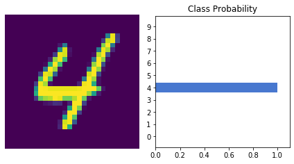

```python
#Data processing for test data
final_test = pd.read_csv("test.csv")
final_test_np = final_test.values/255
test_tn = torch.from_numpy(final_test_np)

# Creating fake labels for convenience of passing into DataLoader
fake_labels = np.zeros(final_test_np.shape)
fake_labels = torch.from_numpy(fake_labels)
submission_tn_data = torch.utils.data.TensorDataset(test_tn, fake_labels)

submission_loader = torch.utils.data.DataLoader(submission_tn_data, batch_size = batch_size, shuffle = False)

# Seeing what our model does on test data
def view_classify(img, ps):
    ''' Function for viewing an image and it's predicted classes.
    '''
    ps = ps.data.numpy().squeeze()

    fig, (ax1, ax2) = plt.subplots(figsize=(6,9), ncols=2)
    ax1.imshow(img.resize_(1, 28, 28).numpy().squeeze())
    ax1.axis('off')
    ax2.barh(np.arange(10), ps)
    ax2.set_aspect(0.1)
    ax2.set_yticks(np.arange(10))
    ax2.set_yticklabels(np.arange(10))
    ax2.set_title('Class Probability')
    ax2.set_xlim(0, 1.1)

    plt.tight_layout()

%matplotlib inline
def make_prediction(data):
    images, labels = next(iter(data))

    img = images[42].view(1, 784)
    # Turn off gradients to speed up this part
    with torch.no_grad():
        logps = model(img.float())

    # Output of the network are log-probabilities, need to take exponential for probabilities
    ps = torch.exp(logps)
    view_classify(img.view(1, 28, 28), ps)


make_prediction(submission_loader)

# Making it submission ready
submission = [['ImageId', 'Label']]

# Turn off gradients for validation
with torch.no_grad():
    model.eval()
    image_id = 1
    for images, _ in submission_loader:
        log_ps = model(images.float())
        ps = torch.exp(log_ps)
        top_p, top_class = ps.topk(1, dim=1)

        for prediction in top_class:
            submission.append([image_id, prediction.item()])
            image_id += 1

submission_df = pd.DataFrame(submission)
submission_df.columns = submission_df.iloc[0]
submission_df = submission_df.drop(0, axis=0)
submission_df.to_csv("submission.csv", index=False)
```

The accuracy of submission file is 97.5% after uploading on Kaggle